# Did Trump **Win** in 2016?

# Introduction

The presidential election in 2020 was and still remains controversial just like it was back in 2016 (though in different aspect), some people still believe that the Democratic party should have won four years ago. In this Exploratory Data Analysis, we will be examining the 2016 Time Series data from The *American National Election Studies* (ANES) and try to answer the question: did Trump really **win** the 2016 presidential election?

The answer to the question “did Trump win in 2016” is YES, but let’s take a moment and think in a deeper level, did he really? The motivation behind this question is that, in a game in which you take part in, if you ended up become the winner of that game, just because the you have won, it does not necessarily mean that you won because you beat your opponent, it could be that your opponent has **lost** the game. In other words, if your opponent did not perform well as expected or there are some external factors affecting their performance, you could have won because you were the person who just happened to be in the spot playing against your opponent.

Disclaimer: the following analysis is not to question or judge the outcome of the 2016 presidential election nor to discredit any work Trump has done, it is only a guide to consider some factors that might have led him become the president for the past four years. We will only look for patterns and trends that are present in the ANES survey data.

# Why Trump?

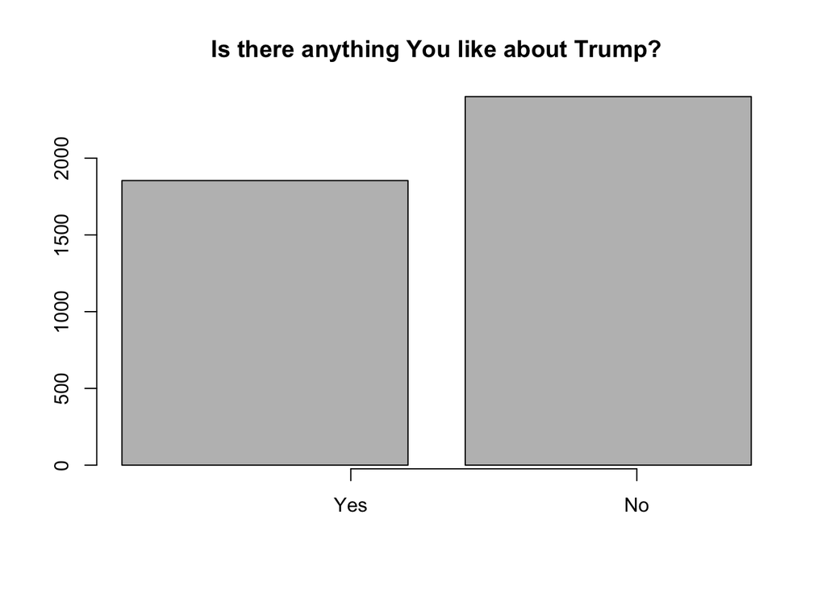

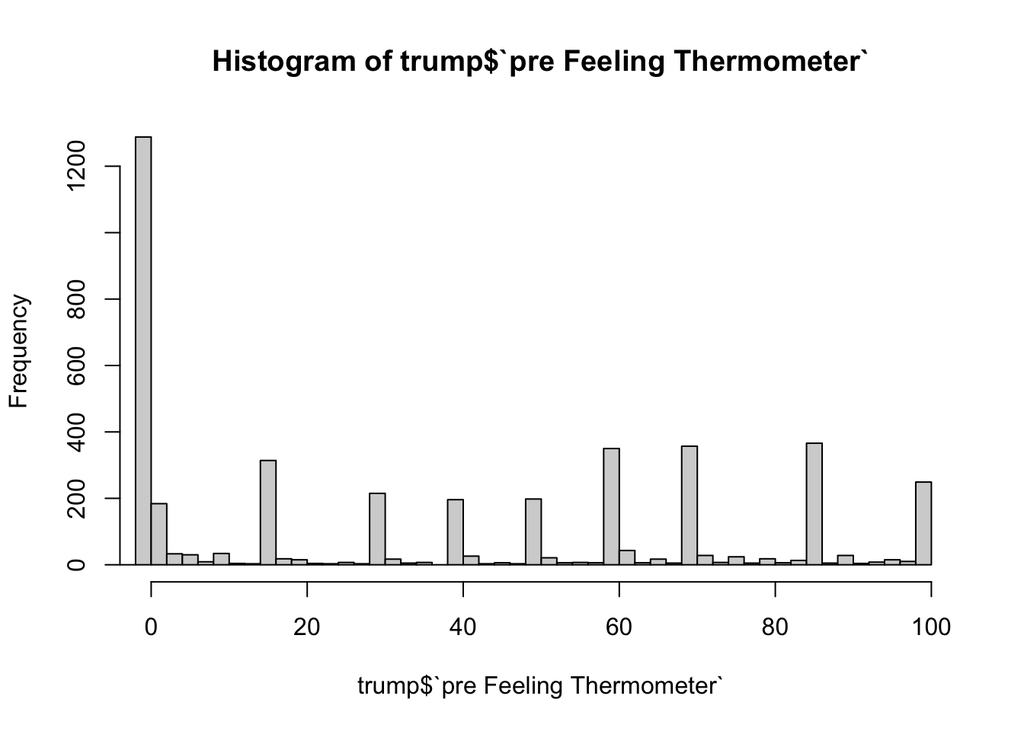

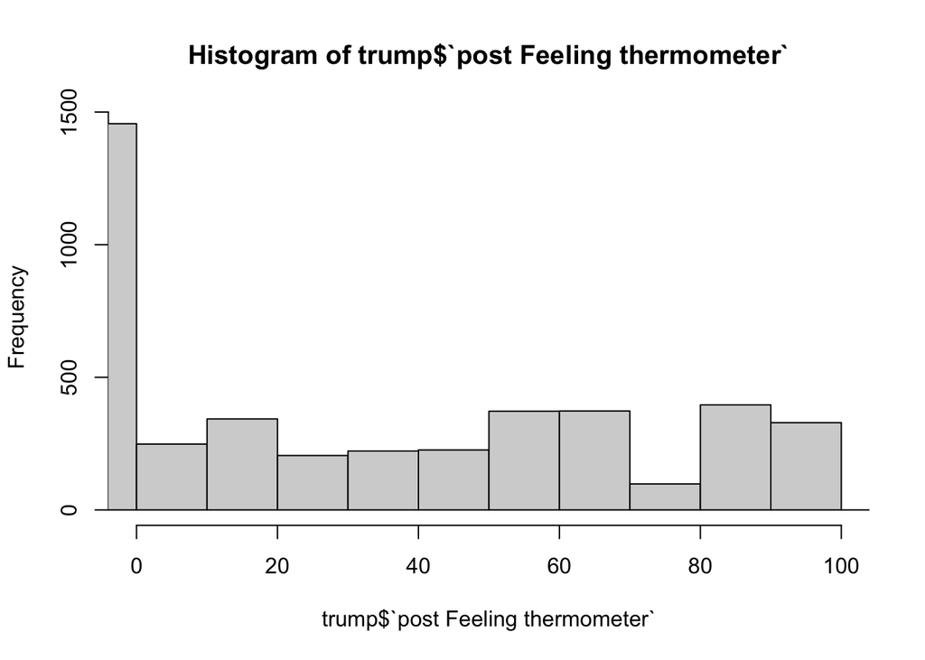

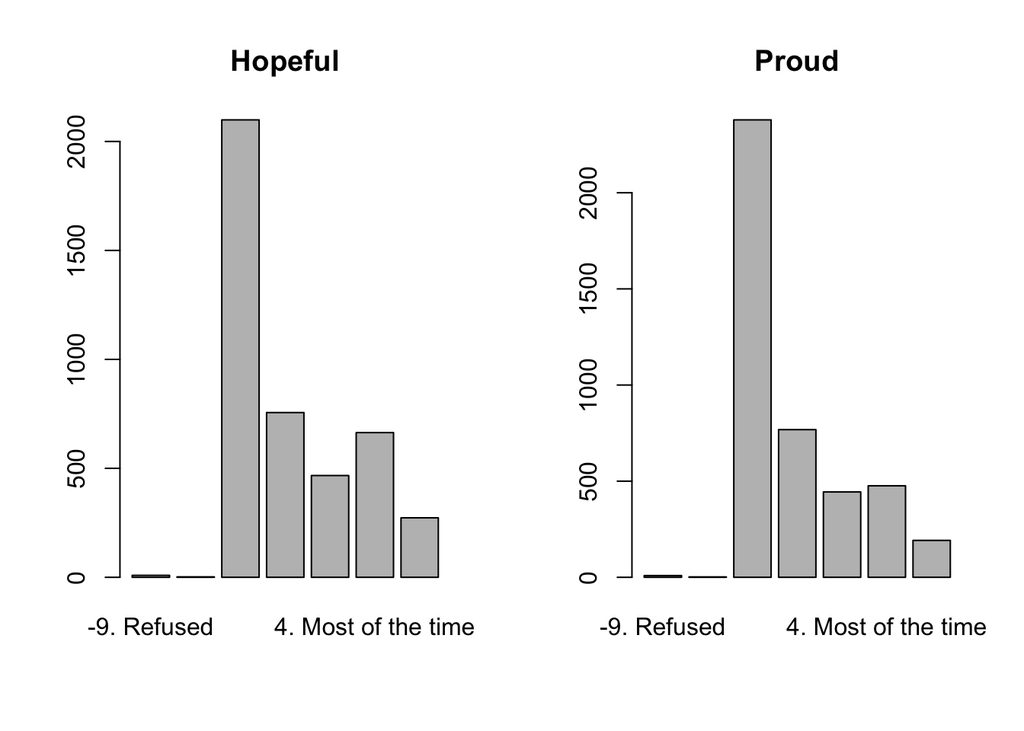

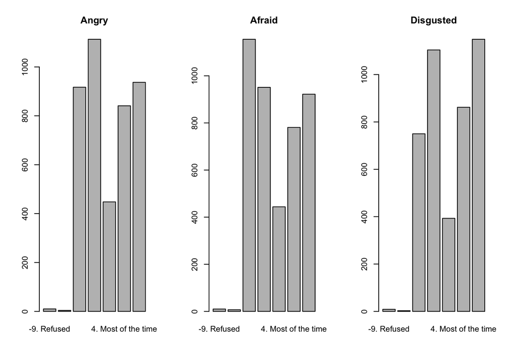

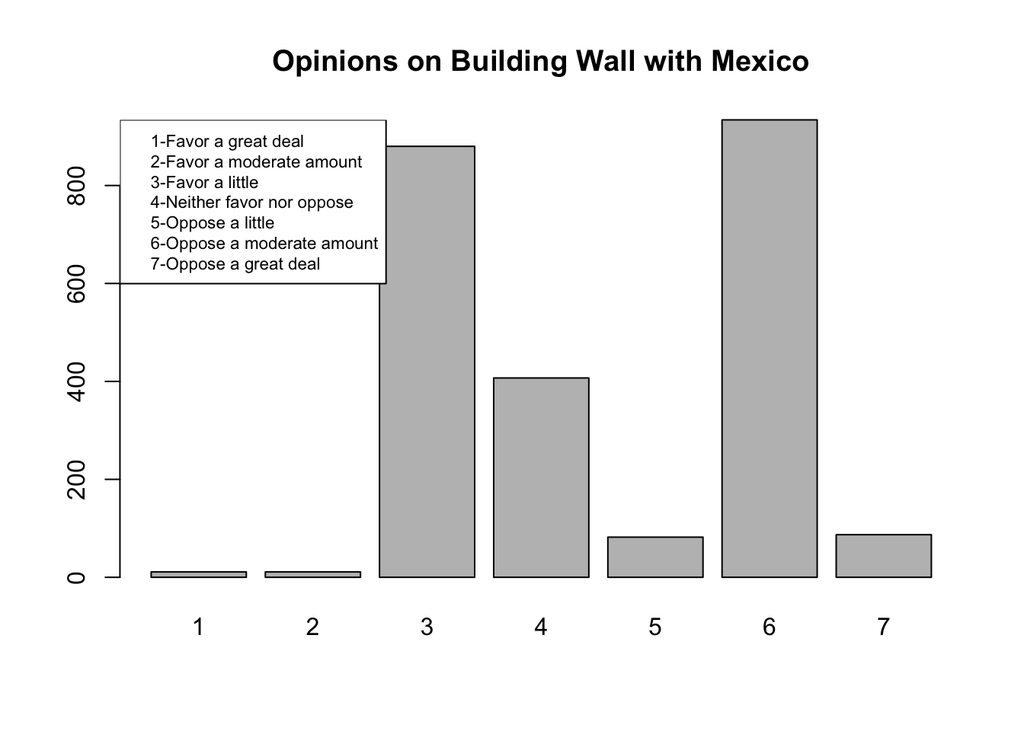

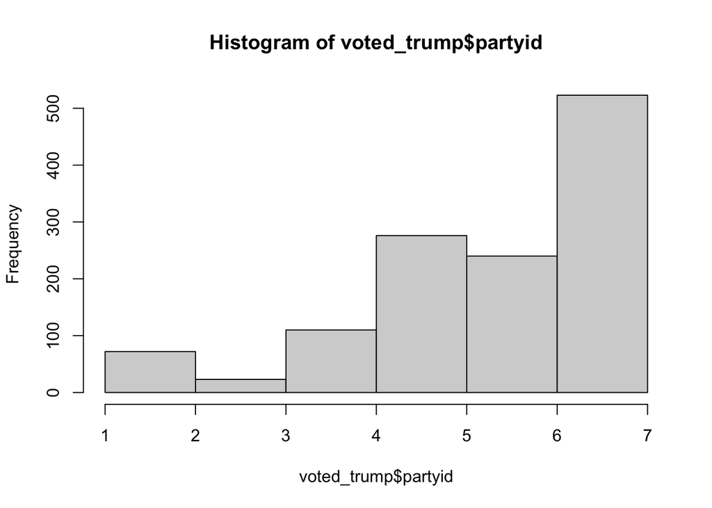

# For the Republicans?

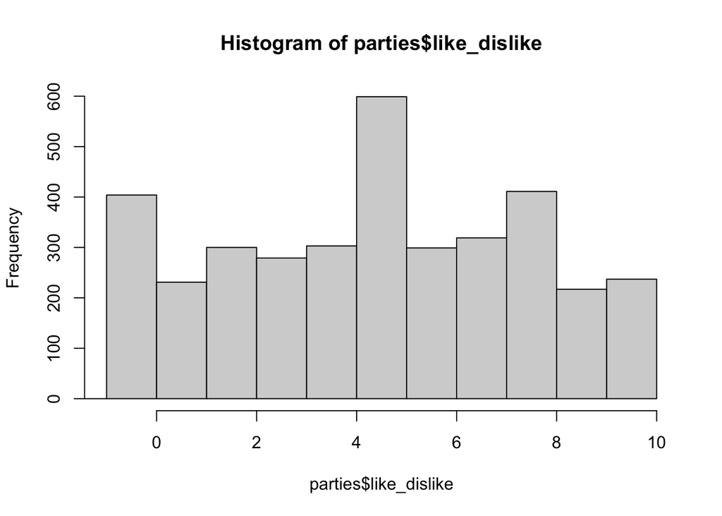

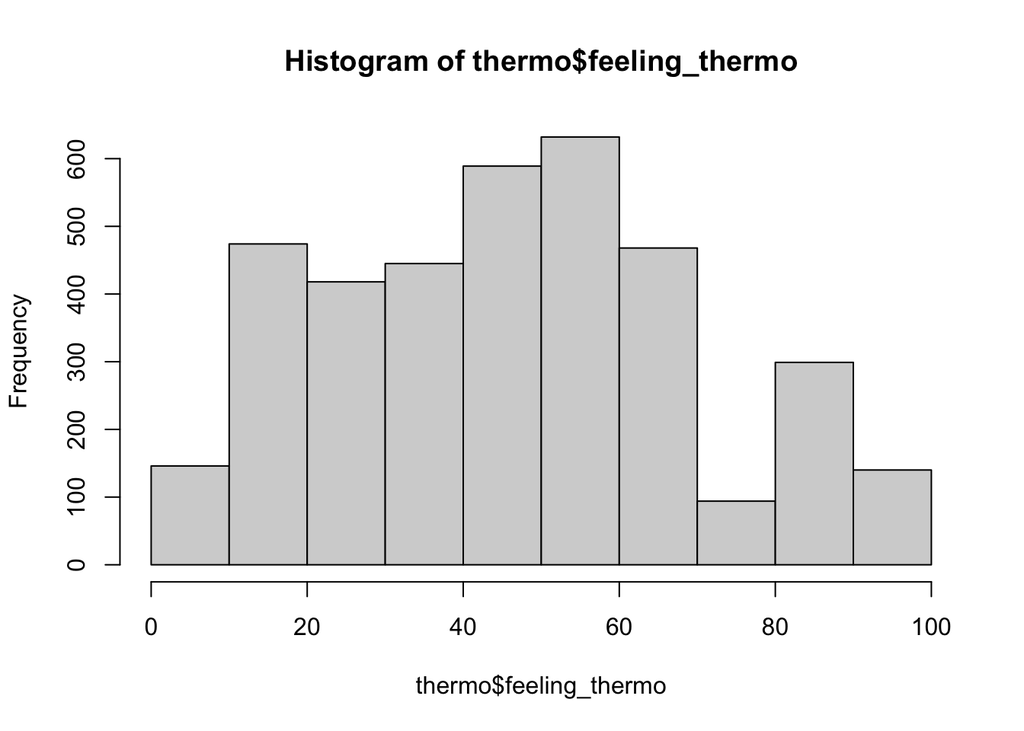

# Against Democrats?

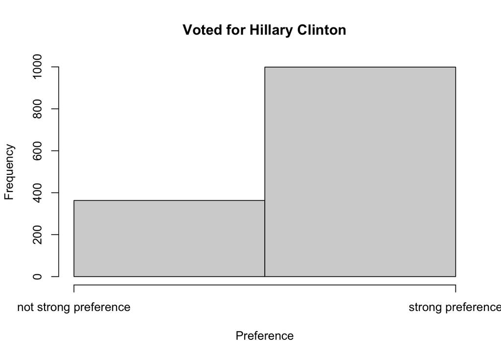

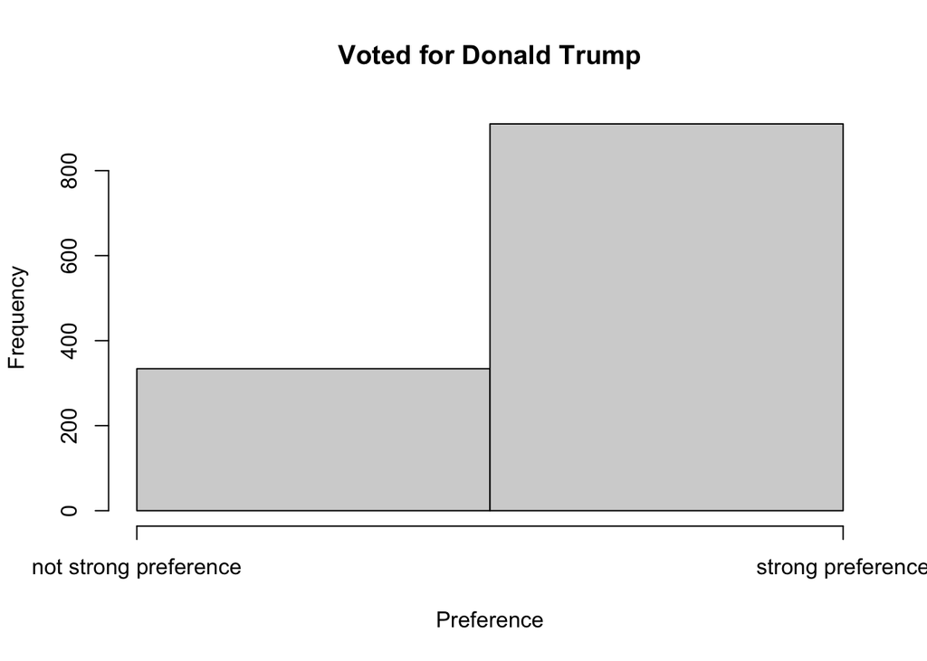